# Phase_3 Project- Data Science

**Student name**: Gladys Kemunto Mosota

**Student pace**: part time

**Scheduled project review date/time**: 1st September 2024, 2.29pm

**Instructor name**: Samuel Karu

**Blog post URL:** git hub repo: https://github.com/Mosota-Kemunto-Gladys-2020/Gladys_phase_3_project.git

### Project Overview

Objective:

SyriaTel, a leading telecommunications company in Syria, is facing substantial financial losses due to customer churn.**Customer churn refers to the rate at which customers discontinue their relationship with a company within a specific period, often due to various reason(s).** In previous projects, SyriaTel focused on descriptive and inferential analyses to understand customer behavior and the relationships between different variables. However, to address the current churn issue, SyriaTel is shifting towards a predictive approach. The goal of this project is to develop a predictive model using the **SyriaTel Customer Churn dataset** that accurately identifies customers at risk of churning. By determining the predictive power of various features and understanding which variables most influence churn, SyriaTel aims to implement targeted retention strategies, reduce churn rates, and ultimately improve customer loyalty and profitability.

### Business Understanding

In the telecommunications industry, customer churn is a critical challenge that directly impacts profitability. For SyriaTel, the loss of customers due to churn is a significant concern, prompting the need for more advanced analytical techniques. Previously, the company focused on descriptive and inferential methods to explore the distributions of key variables and their relationships, gaining valuable insights into customer behavior. However, understanding these relationships alone is no longer sufficient.

To effectively combat churn, SyriaTel is now adopting a predictive approach, which involves building a model that can forecast which customers are likely to churn in the near future. The predictive model will analyze a wide range of features, including customer demographics, usage patterns, and service interactions, to determine their impact on churn.

**Key Questions to Be Addressed:**

1. What is the best model for predicting customer churn?

After comparing various models, including Decision Tree, K-Nearest Neighbors (KNN), and Random Forest, the analysis will recommend the best overall performer. By factoring in accuracy, precision, recall, and ROC-AUC score, the analysis will advise SyriaTel on the most suitable model for predicting churn and implementing targeted retention strategies.

2. How accurately can the model predict customer churn?

The analysis will evaluate the performance of various models using key metrics such as accuracy, precision, recall, and the ROC-AUC score. This evaluation will determine how well the models can predict which customers are likely to churn.

3. Which features are most influential in predicting customer churn?

Identifying the most impactful features, such as customer service interactions, usage patterns, and plan types, will help SyriaTel prioritize its retention efforts and design more effective interventions.

With these predictive insights, SyriaTel can move beyond merely understanding why customers churn to proactively identifying at-risk customers and intervening with targeted strategies. This shift will enable SyriaTel to not only reduce churn rates but also improve customer satisfaction and loyalty, leading to better financial outcomes for the company.

**Methodology for Machine Learning**

To develop a robust predictive model for identifying customers at risk of churning, we will follow a structured methodology that includes the following key steps:

1. Data Understanding
2. Data Cleaning
3. Exploratory Data Analysis
4. Data Preprocessing
5. Modelling
6. Hyperparameter Selection
7. Model Evaluation
8. Recommendations and Conclusion

**Step 1**: Data Understanding

1.1 Import the necessary libraries and modules for dealing with the dataset and its data

```python
import pandas as pd
import numpy as np
import seaborn as sns
import matplotlib.pyplot as plt
%matplotlib inline

from sklearn.model_selection import train_test_split, cross_val_score, cross_validate, GridSearchCV
from sklearn.preprocessing import StandardScaler, MinMaxScaler, OneHotEncoder, FunctionTransformer
from sklearn.metrics import recall_score, accuracy_score, precision_score, f1_score, confusion_matrix, ConfusionMatrixDisplay, classification_report
import scipy.stats as stats
import statsmodels as statsmd
from sklearn.linear_model import LogisticRegression
from sklearn.compose import ColumnTransformer

from imblearn.over_sampling import SMOTE
from imblearn.under_sampling import RandomUnderSampler
from sklearn.pipeline import Pipeline

from sklearn.tree import DecisionTreeClassifier
from sklearn.neighbors import KNeighborsClassifier
from sklearn.dummy import DummyClassifier
from sklearn.ensemble import RandomForestClassifier
```

1.2 Load the Dataset

In this project, the dataset that we chose is called **SyriaTel Customer Churn**.

```python
# Load the dataset and examine its structure.
file_path = 'Data/SyriaTel_Data.csv'
data = pd.read_csv(file_path)

# Display the first few rows of the dataset
data.head()
```

|  | state | account length | area code | phone number | international plan | voice mail plan | number vmail messages | total day minutes | total day calls | total day charge | ... | total eve calls | total eve charge | total night minutes | total night calls | total night charge | total intl minutes | total intl calls | total intl charge | customer service calls | churn |
| --- | --- | --- | --- | --- | --- | --- | --- | --- | --- | --- | --- | --- | --- | --- | --- | --- | --- | --- | --- | --- | --- |
| 0 | KS | 128 | 415 | 382-4657 | no | yes | 25 | 265.1 | 110 | 45.07 | ... | 99 | 16.78 | 244.7 | 91 | 11.01 | 10.0 | 3 | 2.70 | 1 | False |
| 1 | OH | 107 | 415 | 371-7191 | no | yes | 26 | 161.6 | 123 | 27.47 | ... | 103 | 16.62 | 254.4 | 103 | 11.45 | 13.7 | 3 | 3.70 | 1 | False |
| 2 | NJ | 137 | 415 | 358-1921 | no | no | 0 | 243.4 | 114 | 41.38 | ... | 110 | 10.30 | 162.6 | 104 | 7.32 | 12.2 | 5 | 3.29 | 0 | False |
| 3 | OH | 84 | 408 | 375-9999 | yes | no | 0 | 299.4 | 71 | 50.90 | ... | 88 | 5.26 | 196.9 | 89 | 8.86 | 6.6 | 7 | 1.78 | 2 | False |
| 4 | OK | 75 | 415 | 330-6626 | yes | no | 0 | 166.7 | 113 | 28.34 | ... | 122 | 12.61 | 186.9 | 121 | 8.41 | 10.1 | 3 | 2.73 | 3 | False |

5 rows × 21 columns

1.3 Creates a function for viewing the columns in the dataset

```python
def col_info(data):
    print('col_names: \n', data.columns)
    print('num_cols: \n', data.select_dtypes(int).columns)
    print('cat_cols: \n', data.select_dtypes(object).columns)
    print('float_cols: \n', data.select_dtypes(float))
    print('bool_cols : \n' ,data.select_dtypes(bool).columns)

col_info(data)
```

```
col_names:
 Index(['state', 'account length', 'area code', 'phone number',
       'international plan', 'voice mail plan', 'number vmail messages',
       'total day minutes', 'total day calls', 'total day charge',
       'total eve minutes', 'total eve calls', 'total eve charge',
       'total night minutes', 'total night calls', 'total night charge',
       'total intl minutes', 'total intl calls', 'total intl charge',
       'customer service calls', 'churn'],
      dtype='object')
num_cols:
 Index(['account length', 'area code', 'number vmail messages',
       'total day calls', 'total eve calls', 'total night calls',
       'total intl calls', 'customer service calls'],
      dtype='object')
cat_cols:
 Index(['state', 'phone number', 'international plan', 'voice mail plan'], dtype='object')
float_cols:
       total day minutes  total day charge  total eve minutes  \
0                 265.1             45.07              197.4
1                 161.6             27.47              195.5
2                 243.4             41.38              121.2
3                 299.4             50.90               61.9
4                 166.7             28.34              148.3
...                 ...               ...                ...
3328              156.2             26.55              215.5
3329              231.1             39.29              153.4
3330              180.8             30.74              288.8
3331              213.8             36.35              159.6
3332              234.4             39.85              265.9

      total eve charge  total night minutes  total night charge  \
0                16.78                244.7               11.01
1                16.62                254.4               11.45
2                10.30                162.6                7.32
3                 5.26                196.9                8.86
4                12.61                186.9                8.41
...                ...                  ...                 ...
3328             18.32                279.1               12.56
3329             13.04                191.3                8.61
3330             24.55                191.9                8.64
3331             13.57                139.2                6.26
3332             22.60                241.4               10.86

      total intl minutes  total intl charge
0                   10.0               2.70
1                   13.7               3.70
2                   12.2               3.29
3                    6.6               1.78
4                   10.1               2.73
...                  ...                ...
3328                 9.9               2.67
3329                 9.6               2.59
3330                14.1               3.81
3331                 5.0               1.35
3332                13.7               3.70

[3333 rows x 8 columns]
bool_cols :
 Index(['churn'], dtype='object')
```

We observe from the above dataset we observe that there are **21** columns, with a mix of categorical, numerical, and boolean data types. Here's a brief overview of the dataset:

Key Features:

**A). Categorical Features:

1. **state**: Categorical variable indicating the state of the customer.
2. **phone number**: Categorical, the customer's phone number (likely not useful for modeling).
3. **international plan**: Categorical, whether the customer has an international plan (yes/no).
4. **voice mail plan**: Categorical, whether the customer has a voicemail plan (yes/no).

**B). Numerical and Floating Features:

5. **total eve calls**: Integer, total number of calls during the evening.
6. **account length**: Integer, representing the duration of the customer's account in days.
7. **area code**: Integer, indicating the area code of the customer.
8. **total day calls**: Integer, total number of calls during the day.
9. **total night calls**: Integer, total number of calls during the night.
10. **number vmail messages**: Integer, the number of voicemail messages.
11. **customer service calls**: Integer, the number of calls to customer service.
12. **total intl calls**: Integer, total number of international calls.
13. **total day minutes**: Float, total minutes of calls during the day.
14. **total day charge**: Float, total charges for calls during the day.

15 **total eve minutes**: Float, total minutes of calls during the evening.

16. **total eve charge**: Float, total charges for calls during the evening.
17. **total night minutes**: Float, total minutes of calls during the night.
18. **total night charge**: Float, total charges for calls during the night.
19. **total intl minutes**: Float, total minutes of international calls.
20. **total intl charge**: Float, total charges for international calls.

**C) . Boolean Features:

21. **churn**: Boolean, the target variable indicating whether the customer has churned (True) or not (False).

```python
# Display basic information about the dataset
print("\nDataset Info:")
data.info()
```

```
Dataset Info:
<class 'pandas.core.frame.DataFrame'>
RangeIndex: 3333 entries, 0 to 3332
Data columns (total 21 columns):
 #   Column                  Non-Null Count  Dtype
---  ------                  --------------  -----
 0   state                   3333 non-null   object
 1   account length          3333 non-null   int64
 2   area code               3333 non-null   int64
 3   phone number            3333 non-null   object
 4   international plan      3333 non-null   object
 5   voice mail plan         3333 non-null   object
 6   number vmail messages   3333 non-null   int64
 7   total day minutes       3333 non-null   float64
 8   total day calls         3333 non-null   int64
 9   total day charge        3333 non-null   float64
 10  total eve minutes       3333 non-null   float64
 11  total eve calls         3333 non-null   int64
 12  total eve charge        3333 non-null   float64
 13  total night minutes     3333 non-null   float64
 14  total night calls       3333 non-null   int64
 15  total night charge      3333 non-null   float64
 16  total intl minutes      3333 non-null   float64
 17  total intl calls        3333 non-null   int64
 18  total intl charge       3333 non-null   float64
 19  customer service calls  3333 non-null   int64
 20  churn                   3333 non-null   bool
dtypes: bool(1), float64(8), int64(8), object(4)
memory usage: 524.2+ KB
```

1.4 Checking for Missing Values Identify any missing values within the dataset.

Ensuring there are no missing values is crucial, as missing data can lead to inaccuracies in the model training process. If missing values are found, they need to be addressed appropriately.

```python
# Check for missing values
print("\nMissing Values in Each Column:")
print(data.isnull().sum())
```

```
Missing Values in Each Column:
state                     0
account length            0
area code                 0
phone number              0
international plan        0
voice mail plan           0
number vmail messages     0
total day minutes         0
total day calls           0
total day charge          0
total eve minutes         0
total eve calls           0
total eve charge          0
total night minutes       0
total night calls         0
total night charge        0
total intl minutes        0
total intl calls          0
total intl charge         0
customer service calls    0
churn                     0
dtype: int64
```

```python
def cleaning(data):
    missing = data.isna().sum().sum()
    duplicates = data.duplicated().sum()
    return (f"There are {missing} missing values and {duplicates} duplicated values in the dataset")

cleaning(data)
```

```
'There are 0 missing values and 0 duplicated values in the dataset'
```

```python
# Checking for unique values
data.nunique()
```

```
state                       51
account length             212
area code                    3
phone number              3333
international plan           2
voice mail plan              2
number vmail messages       46
total day minutes         1667
total day calls            119
total day charge          1667
total eve minutes         1611
total eve calls            123
total eve charge          1440
total night minutes       1591
total night calls          120
total night charge         933
total intl minutes         162
total intl calls            21
total intl charge          162
customer service calls      10
churn                        2
dtype: int64
```

```python
data.shape
```

```
(3333, 21)
```

From this dataset, we can observe that there are **3,333** rows and **21** columns, from which it's distributed evenly. We can also observe that we didn't have any missing values or duplicated values in the dataset and this enabled us to conduct this project without any challenges.

**Step 2**: Data Cleaning

Now that we understand the structure of the data, we'll clean it by addressing any issues such as missing values or irrelevant columns.

2.1 Drop Irrelevant Features

Remove columns that are not useful for prediction, such as identifiers like the phone number.

```python
# Drop irrelevant columns
data = data.drop(columns=['phone number'])

# Check the updated dataframe
print("\nFirst Few Rows After Dropping Irrelevant Columns:")
data.head()
```

```
First Few Rows After Dropping Irrelevant Columns:
```

|  | state | account length | area code | international plan | voice mail plan | number vmail messages | total day minutes | total day calls | total day charge | total eve minutes | total eve calls | total eve charge | total night minutes | total night calls | total night charge | total intl minutes | total intl calls | total intl charge | customer service calls | churn |
| --- | --- | --- | --- | --- | --- | --- | --- | --- | --- | --- | --- | --- | --- | --- | --- | --- | --- | --- | --- | --- |
| 0 | KS | 128 | 415 | no | yes | 25 | 265.1 | 110 | 45.07 | 197.4 | 99 | 16.78 | 244.7 | 91 | 11.01 | 10.0 | 3 | 2.70 | 1 | False |
| 1 | OH | 107 | 415 | no | yes | 26 | 161.6 | 123 | 27.47 | 195.5 | 103 | 16.62 | 254.4 | 103 | 11.45 | 13.7 | 3 | 3.70 | 1 | False |
| 2 | NJ | 137 | 415 | no | no | 0 | 243.4 | 114 | 41.38 | 121.2 | 110 | 10.30 | 162.6 | 104 | 7.32 | 12.2 | 5 | 3.29 | 0 | False |
| 3 | OH | 84 | 408 | yes | no | 0 | 299.4 | 71 | 50.90 | 61.9 | 88 | 5.26 | 196.9 | 89 | 8.86 | 6.6 | 7 | 1.78 | 2 | False |
| 4 | OK | 75 | 415 | yes | no | 0 | 166.7 | 113 | 28.34 | 148.3 | 122 | 12.61 | 186.9 | 121 | 8.41 | 10.1 | 3 | 2.73 | 3 | False |

**Step 3**: Exploratory Data Analysis (EDA)

3.1 Descriptive Statistics

```python
# Display descriptive statistics
print("\nDescriptive Statistics of the Dataset:")
data.describe()
```

```
Descriptive Statistics of the Dataset:
```

|  | account length | area code | number vmail messages | total day minutes | total day calls | total day charge | total eve minutes | total eve calls | total eve charge | total night minutes | total night calls | total night charge | total intl minutes | total intl calls | total intl charge | customer service calls |
| --- | --- | --- | --- | --- | --- | --- | --- | --- | --- | --- | --- | --- | --- | --- | --- | --- |
| count | 3333.000000 | 3333.000000 | 3333.000000 | 3333.000000 | 3333.000000 | 3333.000000 | 3333.000000 | 3333.000000 | 3333.000000 | 3333.000000 | 3333.000000 | 3333.000000 | 3333.000000 | 3333.000000 | 3333.000000 | 3333.000000 |
| mean | 101.064806 | 437.182418 | 8.099010 | 179.775098 | 100.435644 | 30.562307 | 200.980348 | 100.114311 | 17.083540 | 200.872037 | 100.107711 | 9.039325 | 10.237294 | 4.479448 | 2.764581 | 1.562856 |
| std | 39.822106 | 42.371290 | 13.688365 | 54.467389 | 20.069084 | 9.259435 | 50.713844 | 19.922625 | 4.310668 | 50.573847 | 19.568609 | 2.275873 | 2.791840 | 2.461214 | 0.753773 | 1.315491 |
| min | 1.000000 | 408.000000 | 0.000000 | 0.000000 | 0.000000 | 0.000000 | 0.000000 | 0.000000 | 0.000000 | 23.200000 | 33.000000 | 1.040000 | 0.000000 | 0.000000 | 0.000000 | 0.000000 |
| 25% | 74.000000 | 408.000000 | 0.000000 | 143.700000 | 87.000000 | 24.430000 | 166.600000 | 87.000000 | 14.160000 | 167.000000 | 87.000000 | 7.520000 | 8.500000 | 3.000000 | 2.300000 | 1.000000 |
| 50% | 101.000000 | 415.000000 | 0.000000 | 179.400000 | 101.000000 | 30.500000 | 201.400000 | 100.000000 | 17.120000 | 201.200000 | 100.000000 | 9.050000 | 10.300000 | 4.000000 | 2.780000 | 1.000000 |
| 75% | 127.000000 | 510.000000 | 20.000000 | 216.400000 | 114.000000 | 36.790000 | 235.300000 | 114.000000 | 20.000000 | 235.300000 | 113.000000 | 10.590000 | 12.100000 | 6.000000 | 3.270000 | 2.000000 |
| max | 243.000000 | 510.000000 | 51.000000 | 350.800000 | 165.000000 | 59.640000 | 363.700000 | 170.000000 | 30.910000 | 395.000000 | 175.000000 | 17.770000 | 20.000000 | 20.000000 | 5.400000 | 9.000000 |

The table provides a summary of key statistics (count, mean, standard deviation, minimum, 25th percentile, median, 75th percentile, and maximum) for various features in the dataset. These statistics are crucial for understanding the distribution of the data and identifying potential outliers.

Key Observations:

**Range and Potential Outliers:**

- number vmail messages: The maximum value is 51, while the 75th percentile is 20, indicating that a small subset of users has a much higher number of voicemail messages, potentially marking them as outliers.
- total day minutes, total eve minutes, total night minutes, total intl minutes: These features have maximum values significantly higher than the 75th percentile. For example, total day minutes has a max of 350.8 minutes, whereas the 75th percentile is 216.4 minutes, suggesting the presence of outliers.
- customer service calls: The maximum number of calls is 9, with a median of 1 and a 75th percentile of 2. This suggests that while most customers have 1-2 service calls, some customers are outliers with significantly higher call counts.

Conclusion:

- **Outliers**: Several features show potential outliers, particularly in the number vmail messages, total day minutes, total eve minutes, total night minutes, total intl minutes, and customer service calls fields. These outliers could significantly impact the model’s performance if not addressed.
- **Next Steps**: We will consider handling these outliers, possibly by capping extreme values, using robust scaling methods, or investigating the reasons behind these outlier behaviors. Additionally, further visualization (e.g., box plots) could help confirm and understand the distribution and impact of these outliers.

3.2 Distribution of the Target Variable (Churn)

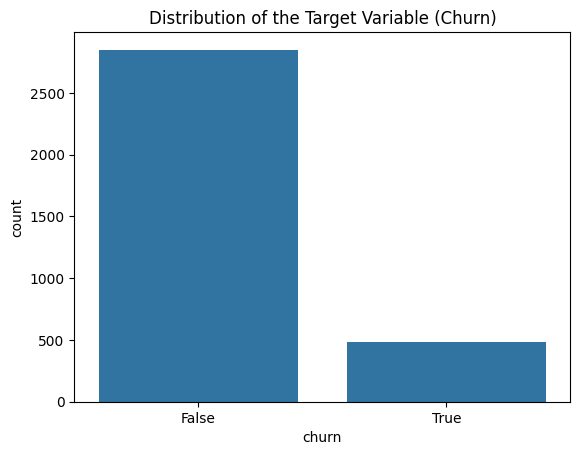

```python
import seaborn as sns
import matplotlib.pyplot as plt

# Plot distribution of the target variable
sns.countplot(x='churn', data=data)
plt.title('Distribution of the Target Variable (Churn)')
plt.show()
```

The bar chart above shows the distribution of the target variable "churn," indicating whether customers have churned (left the service) or not.

Interpretation:

**False (Non-Churners): The taller bar represents customers who have not churned. This group is significantly larger, with over 2,500 customers.**

**True (Churners): The shorter bar represents customers who have churned. This group is much smaller, with fewer than 500 customers.**

Key Insights:

Class Imbalance: The chart highlights a clear class imbalance in the dataset. The majority of customers have not churned, while a relatively small number have. This imbalance is crucial to consider when building predictive models, as it can lead to a model that is biased toward predicting the majority class (non-churners).

Handling Imbalance: Techniques such as oversampling the minority class (using SMOTE, for example) or undersampling the majority class may be necessary to ensure that the model accurately predicts both classes.

This imbalance will be addressed during the preprocessing or model training phase to improve the model's performance in predicting customer churn.

3.3 Visualize the Distribution of Numerical Features

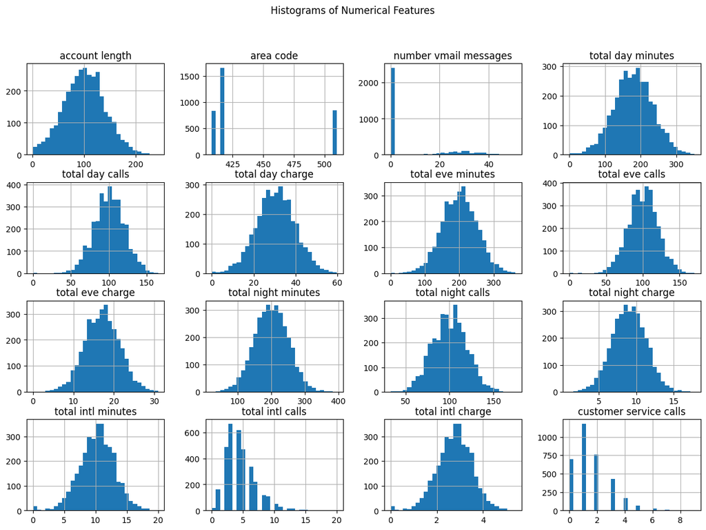

```python
# Plot histograms of numerical features
data.hist(bins=30, figsize=(15, 10))
plt.suptitle('Histograms of Numerical Features')
plt.show()
```

Most features are normally distributed , so log transformation is not necessary for them. However,features with Skewed Distributions like Number Vmail Messages(This feature is heavily right-skewed, with most values concentrated at zero and a long tail of higher values.); Customer Service Calls(This feature is also right-skewed, with the majority of customers making very few calls, and a smaller number making a higher number of calls.) and Total Intl Calls( This feature shows some skewness, though it is less extreme than the first two.) we may consider log transformation

The image shows a series of histograms that represent the distribution of various numerical features in the dataset. Here’s the interpretation of each feature based on the histograms:

Key Insights:

Normal Distributions: Many features, such as total minutes, total calls, and corresponding charges, follow normal distributions. This suggests that most customers have similar usage patterns, with a typical range of values for these features.

Skewed Distributions: The "number vmail messages" and "customer service calls" features are skewed. Most customers do not use voicemail services much, and most do not frequently call customer service.

Area Code: The area code feature is categorical with three main groups, indicating that the dataset represents customers from three distinct regions.

Implications for Modeling:

Feature Scaling: Given the normal distribution of most features, feature scaling (e.g., standardization) will likely be beneficial for models that are sensitive to the scale of input data (e.g., logistic regression, SVM).

Handling Skewness: For skewed features like "number vmail messages" and "customer service calls," special attention might be needed. For example, you could apply log transformation to reduce skewness if using models that assume normally distributed data.

Categorical Handling: The area code, despite being numerical, is more categorical in nature and should be treated accordingly (e.g., using one-hot encoding) in the modeling process.

These insights can help in deciding which preprocessing steps to apply and in understanding the underlying patterns in the data.

3.4 Caterogical feature distributions

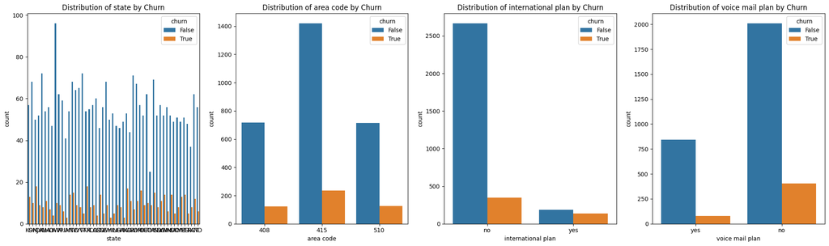

```python
# List of categorical features
categorical_features = ['state','area code' ,'international plan', 'voice mail plan']

# Create subplots: 1 row and 3 columns
fig, axes = plt.subplots(nrows=1, ncols=len(categorical_features), figsize=(20, 6))

# Loop through each feature and create a count plot
for i, feature in enumerate(categorical_features):
    sns.countplot(x=feature, hue='churn', data=data, ax=axes[i])
    axes[i].set_title(f'Distribution of {feature} by Churn')

plt.tight_layout()
plt.show()
```

3.5 Checking for outliers

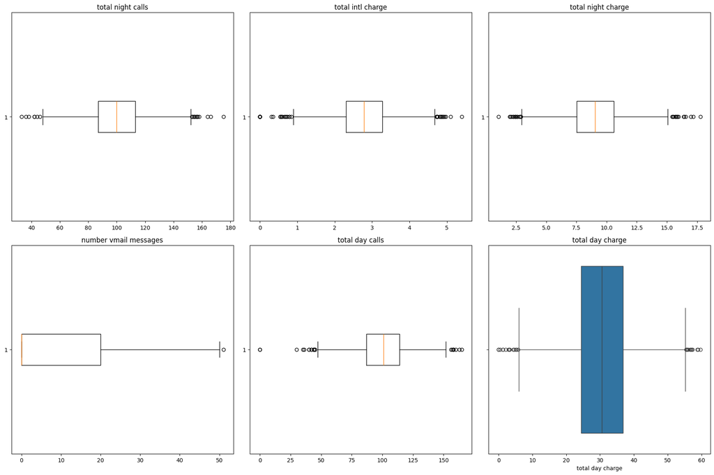

```python
# Define the list of numerical columns
num_cols = ["total night calls", "total intl charge", "total night charge", "number vmail messages"]

# Create a figure with multiple subplots
fig, axes = plt.subplots(nrows=2, ncols=3, figsize=(18, 12))  # Adjusting layout for all plots

# Plot each of the specified columns in the first row and second row as needed
for i, col in enumerate(num_cols):
    if i < 3:  # Plot on the first row
        axes[0, i].boxplot(data[col], vert=False)
        axes[0, i].set_title(col)
    else:  # Plot on the first position of the second row
        axes[1, 0].boxplot(data[col], vert=False)
        axes[1, 0].set_title(col)

# Plot the additional boxplots in the remaining positions of the second row
axes[1, 1].boxplot(data['total day calls'], vert=False)
axes[1, 1].set_title('total day calls')

sns.boxplot(data=data, x='total day charge', ax=axes[1, 2])
axes[1, 2].set_title('total day charge')

plt.tight_layout()
plt.show()
```

**Summary of above visualisations:**

Distribution: Most features are symmetrically distributed around their medians, except for number of voicemail messages, which shows significant skewness.

Considerations: The outliers could impact the model's performance and may need to be addressed depending on their significance to the business problem.

3.6 Correlation Analysis

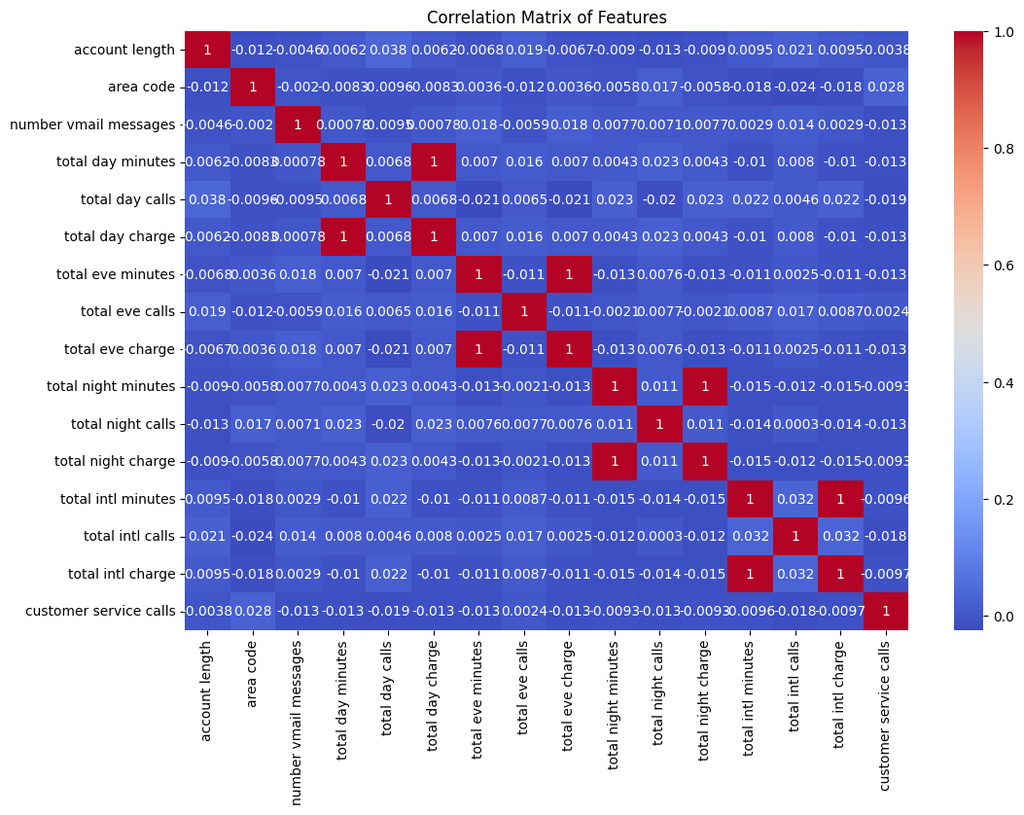

```python
# Select only the numeric columns
numeric_df = data.select_dtypes(include=[np.number])

# Calculate the correlation matrix
corr_matrix = numeric_df.corr()

# Visualize the correlation matrix
plt.figure(figsize=(12, 8))
sns.heatmap(corr_matrix, annot=True, cmap='coolwarm')
plt.title('Correlation Matrix of Features')
plt.show()
```

The correlation matrix visually represents the linear relationships between pairs of features in the dataset. Key observations include:

Perfect Correlations: Features like total day minutes and total day charge, total eve minutes and total eve charge, total night minutes and total night charge, and total intl minutes and total intl charge have perfect correlations (correlation coefficient = 1). This is expected because the charges are directly proportional to the minutes used.

Low Correlation with Target: Features such as customer service calls, account length, and number vmail messages have very low correlation with other features, suggesting they provide unique information.

Potential Redundancy: Features with perfect correlations might be redundant and could be candidates for removal in modeling to reduce multicollinearity.

This matrix is useful for identifying which features are highly correlated and may need to be handled carefully to avoid issues in model training, such as multicollinearity.

Potential Redundancy in Features: In the correlation matrix, the following pairs of features show a perfect correlation (correlation coefficient = 1). These pairs are redundant because one feature in each pair is a linear transformation of the other. When building models, you might consider removing one feature from each pair to reduce multicollinearity:

Total Day Minutes and Total Day Charge:

Both features are perfectly correlated (correlation = 1). Since charges are typically a direct function of minutes used, you can consider removing one of these features. Total Eve Minutes and Total Eve Charge:

These two features also have a perfect correlation. Removing one of these would reduce redundancy. Total Night Minutes and Total Night Charge:

Like the day and evening features, these are perfectly correlated, and one can be removed. Total Intl Minutes and Total Intl Charge:

These features are perfectly correlated as well, making one of them redundant.

Suggested Action: we will remove One Feature from Each Pair: For each of the above pairs, consider keeping only one feature (either the minutes or the charge) to simplify the model and avoid multicollinearity issues. Typically, you'd keep the feature that is more directly related to the business problem or has a more straightforward interpretation.

**Step 4:** Preprocessing

4.1 Train-Test Split

Split the data into training and testing sets before performing any transformations.

```python
from sklearn.model_selection import train_test_split

# Split the data into features (X) and target (y)
X = data.drop(columns=['churn'])
y = data['churn']

# Split into training and testing sets
X_train, X_test, y_train, y_test = train_test_split(X, y, test_size=0.2, random_state=42)

print(f"Training Set: {X_train.shape}, {y_train.shape}")
print(f"Testing Set: {X_test.shape}, {y_test.shape}")
```

```
Training Set: (2666, 19), (2666,)
Testing Set: (667, 19), (667,)
```

```python
from sklearn.model_selection import train_test_split

# Assuming X and y are the full feature set and labels
X_train, X_test, y_train, y_test = train_test_split(X, y, test_size=0.2, random_state=42)

# Verify the split sizes
print(f"X_test shape: {X_test.shape}, y_test shape: {y_test.shape}")
```

```
X_test shape: (667, 19), y_test shape: (667,)
```

4.2 Encoding Categorical Variables

Now that the data is split, we proceed to encode the categorical variables in both the training and test sets.

4.2.1: One-Hot Encode Categorical Variables for Training Set

```python
# One-hot encode categorical variables for training set
X_train_encoded = pd.get_dummies(X_train, drop_first=True)

# Check the encoded training dataframe
print("\nFirst Few Rows After Encoding Categorical Variables (Training Set):")
X_train_encoded.head()
```

```
First Few Rows After Encoding Categorical Variables (Training Set):
```

|  | account length | area code | number vmail messages | total day minutes | total day calls | total day charge | total eve minutes | total eve calls | total eve charge | total night minutes | ... | state_TX | state_UT | state_VA | state_VT | state_WA | state_WI | state_WV | state_WY | international plan_yes | voice mail plan_yes |
| --- | --- | --- | --- | --- | --- | --- | --- | --- | --- | --- | --- | --- | --- | --- | --- | --- | --- | --- | --- | --- | --- |
| 817 | 243 | 510 | 0 | 95.5 | 92 | 16.24 | 163.7 | 63 | 13.91 | 264.2 | ... | False | True | False | False | False | False | False | False | False | False |
| 1373 | 108 | 415 | 0 | 112.0 | 105 | 19.04 | 193.7 | 110 | 16.46 | 208.9 | ... | False | False | False | False | False | False | False | False | False | False |
| 679 | 75 | 415 | 0 | 222.4 | 78 | 37.81 | 327.0 | 111 | 27.80 | 208.0 | ... | True | False | False | False | False | False | False | False | True | False |
| 56 | 141 | 415 | 0 | 126.9 | 98 | 21.57 | 180.0 | 62 | 15.30 | 140.8 | ... | False | False | False | False | False | False | False | False | False | False |
| 1993 | 86 | 510 | 0 | 216.3 | 96 | 36.77 | 266.3 | 77 | 22.64 | 214.0 | ... | False | False | False | False | False | False | False | False | False | False |

5 rows × 68 columns

4.2.2 : One-Hot Encode Categorical Variables for Testing Set

```python
# One-hot encode categorical variables for test set
X_test_encoded = pd.get_dummies(X_test, drop_first=True)

# Check the encoded testing dataframe
print("\nFirst Few Rows After Encoding Categorical Variables (Testing Set):")
print(X_test_encoded.head())
```

```
First Few Rows After Encoding Categorical Variables (Testing Set):
      account length  area code  number vmail messages  total day minutes  \
438              113        510                      0              155.0
2674              67        415                      0              109.1
1345              98        415                      0                0.0
1957             147        408                      0              212.8
2148              96        408                      0              144.0

      total day calls  total day charge  total eve minutes  total eve calls  \
438                93             26.35              330.6              106
2674              117             18.55              217.4              124
1345                0              0.00              159.6              130
1957               79             36.18              204.1               91
2148              102             24.48              224.7               73

```

[output cut: 22 more lines]

```python
# One-hot encode categorical variables for training set
X_train_encoded = pd.get_dummies(X_train, drop_first=True)

# One-hot encode categorical variables for test set
X_test_encoded = pd.get_dummies(X_test, drop_first=True)

# Align the test set with the training set columns (handle any missing columns in test set)
X_train_encoded, X_test_encoded = X_train_encoded.align(X_test_encoded, join='left', axis=1, fill_value=0)

# Check the encoded training dataframe
print("\nFirst Few Rows After Encoding Categorical Variables (Training Set):")
print(X_train_encoded.head())

# Check the encoded testing dataframe
print("\nFirst Few Rows After Encoding Categorical Variables (Testing Set):")

X_test_encoded.head()
```

```
First Few Rows After Encoding Categorical Variables (Training Set):
      account length  area code  number vmail messages  total day minutes  \
817              243        510                      0               95.5
1373             108        415                      0              112.0
679               75        415                      0              222.4
56               141        415                      0              126.9
1993              86        510                      0              216.3

      total day calls  total day charge  total eve minutes  total eve calls  \
817                92             16.24              163.7               63
1373              105             19.04              193.7              110
679                78             37.81              327.0              111
56                 98             21.57              180.0               62
1993               96             36.77              266.3               77

      total eve charge  total night minutes  ...  state_TX  state_UT  \
817              13.91                264.2  ...     False      True
1373             16.46                208.9  ...     False     False
679              27.80                208.0  ...      True     False
56               15.30                140.8  ...     False     False
1993             22.64                214.0  ...     False     False

      state_VA  state_VT  state_WA  state_WI  state_WV  state_WY  \
817      False     False     False     False     False     False
1373     False     False     False     False     False     False
679      False     False     False     False     False     False
56       False     False     False     False     False     False
1993     False     False     False     False     False     False

      international plan_yes  voice mail plan_yes
817                    False                False
1373                   False                False
679                     True                False
56                     False                False
1993                   False                False

[5 rows x 68 columns]

First Few Rows After Encoding Categorical Variables (Testing Set):
```

|  | account length | area code | number vmail messages | total day minutes | total day calls | total day charge | total eve minutes | total eve calls | total eve charge | total night minutes | ... | state_TX | state_UT | state_VA | state_VT | state_WA | state_WI | state_WV | state_WY | international plan_yes | voice mail plan_yes |
| --- | --- | --- | --- | --- | --- | --- | --- | --- | --- | --- | --- | --- | --- | --- | --- | --- | --- | --- | --- | --- | --- |
| 438 | 113 | 510 | 0 | 155.0 | 93 | 26.35 | 330.6 | 106 | 28.10 | 189.4 | ... | False | False | False | False | False | False | False | True | False | False |
| 2674 | 67 | 415 | 0 | 109.1 | 117 | 18.55 | 217.4 | 124 | 18.48 | 188.4 | ... | False | False | False | False | False | False | False | False | False | False |
| 1345 | 98 | 415 | 0 | 0.0 | 0 | 0.00 | 159.6 | 130 | 13.57 | 167.1 | ... | False | False | False | False | False | False | False | False | False | False |
| 1957 | 147 | 408 | 0 | 212.8 | 79 | 36.18 | 204.1 | 91 | 17.35 | 156.2 | ... | False | False | False | False | False | False | False | False | False | False |
| 2148 | 96 | 408 | 0 | 144.0 | 102 | 24.48 | 224.7 | 73 | 19.10 | 227.7 | ... | False | False | False | False | False | False | False | True | False | False |

5 rows × 68 columns

4.2.3 : Align the Test Set with the Training Set Columns After encoding, it's important to align the test set with the training set to ensure that both datasets have the same features. Any missing columns in the test set will be added and filled with zeros.

```python
# Align the test set with the training set columns (handle any missing columns in test set)
X_train_encoded, X_test_encoded = X_train_encoded.align(X_test_encoded, join='left', axis=1, fill_value=0)

# Check the aligned training dataframe
print("\nFirst Few Rows After Aligning Categorical Variables (Training Set):")
print(X_train_encoded.head())

# Check the aligned testing dataframe
print("\nFirst Few Rows After Aligning Categorical Variables (Testing Set):")
print(X_test_encoded.head())
```

```
First Few Rows After Aligning Categorical Variables (Training Set):
      account length  area code  number vmail messages  total day minutes  \
817              243        510                      0               95.5
1373             108        415                      0              112.0
679               75        415                      0              222.4
56               141        415                      0              126.9
1993              86        510                      0              216.3

      total day calls  total day charge  total eve minutes  total eve calls  \
817                92             16.24              163.7               63
1373              105             19.04              193.7              110
679                78             37.81              327.0              111
56                 98             21.57              180.0               62
1993               96             36.77              266.3               77

      total eve charge  total night minutes  ...  state_TX  state_UT  \
817              13.91                264.2  ...     False      True
1373             16.46                208.9  ...     False     False
679              27.80                208.0  ...      True     False
56               15.30                140.8  ...     False     False
1993             22.64                214.0  ...     False     False

      state_VA  state_VT  state_WA  state_WI  state_WV  state_WY  \
817      False     False     False     False     False     False
1373     False     False     False     False     False     False
679      False     False     False     False     False     False
56       False     False     False     False     False     False
1993     False     False     False     False     False     False

      international plan_yes  voice mail plan_yes
817                    False                False
1373                   False                False
679                     True                False
56                     False                False
1993                   False                False

[5 rows x 68 columns]

First Few Rows After Aligning Categorical Variables (Testing Set):
      account length  area code  number vmail messages  total day minutes  \
```

[output cut: 20 more lines]

```
      state_VA  state_VT  state_WA  state_WI  state_WV  state_WY  \
438      False     False     False     False     False      True
2674     False     False     False     False     False     False
1345     False     False     False     False     False     False
1957     False     False     False     False     False     False
2148     False     False     False     False     False      True

      international plan_yes  voice mail plan_yes
438                    False                False
2674                   False                False
1345                   False                False
1957                   False                False
2148                   False                False

[5 rows x 68 columns]
```

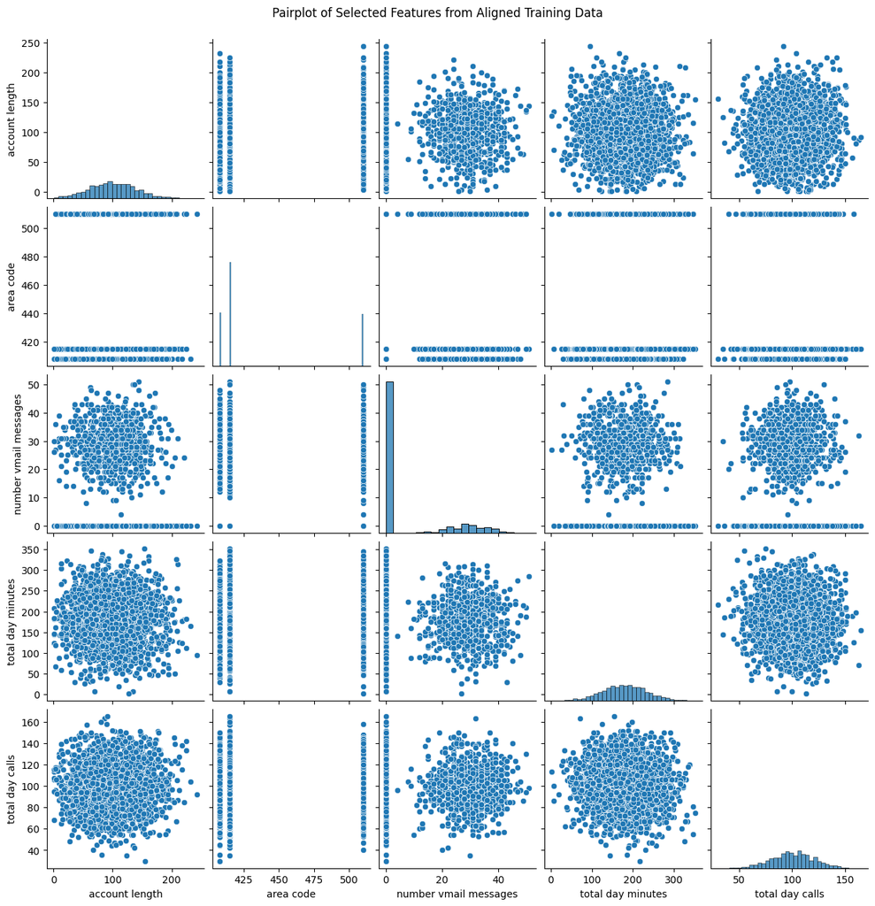

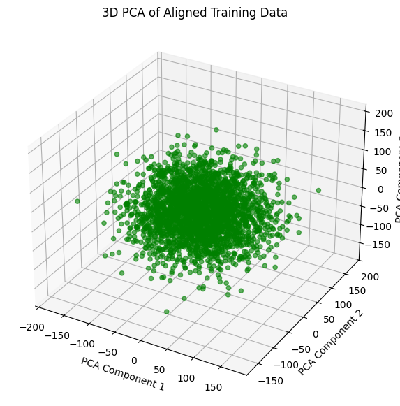

```python
import seaborn as sns
import matplotlib.pyplot as plt
from sklearn.decomposition import PCA
import pandas as pd


# 1. Pairplot for Selected Features
# Selecting first 5 features for pairplot; adjust based on your data size or focus
plt.figure(figsize=(15, 10))
sns.pairplot(X_train_encoded.iloc[:, :5])  # Adjust the selection as necessary
plt.suptitle('Pairplot of Selected Features from Aligned Training Data', y=1.02)
plt.show()

# 2. 3D PCA Visualization
pca = PCA(n_components=3)
X_train_pca_3d = pca.fit_transform(X_train_encoded)

fig = plt.figure(figsize=(10, 7))
ax = fig.add_subplot(111, projection='3d')
ax.scatter(X_train_pca_3d[:, 0], X_train_pca_3d[:, 1], X_train_pca_3d[:, 2], c='green', alpha=0.6)
ax.set_title('3D PCA of Aligned Training Data')
ax.set_xlabel('PCA Component 1')
ax.set_ylabel('PCA Component 2')
ax.set_zlabel('PCA Component 3')
plt.show()
```

Summary of Visualizations

1. Pairplot of Selected Features:

The pairplot shows the relationships between five selected features from the aligned training data: account length, area code, number of voicemail messages, total day minutes, and total day calls.

Most features exhibit a symmetric distribution with no apparent strong correlations between the selected features.

The categorical nature of area codes is visible with three distinct values, while the other features show more continuous distributions.

2. 3D PCA of Aligned Training Data:

The 3D PCA plot visualizes the data across three principal components, which capture the main directions of variance in the dataset.

The data points are densely clustered around the center, indicating that the main patterns in the data do not vary widely across these principal components.

There are no distinct separations or clusters, suggesting the features are relatively homogeneous in terms of their principal components.

These visualizations provide insights into the distribution and variance of the dataset, helping to understand how the data might behave in predictive modeling.

Why This Approach is Important: Consistency: Ensures that the training and test sets have the same features, which is crucial for applying machine learning models. Handling Missing Categories: In some cases, the test set might not have all the categories present in the training set. Aligning ensures that these differences do not cause errors during model training or prediction.

4.3 Feature Scaling

Scale the features in both the training and test sets using the same Scaler to ensure consistency.

4.3.1 Scaling the Training Set

Fit the Scaler: The StandardScaler is first fitted to the X_train_encoded data. This means that the scaler calculates the mean and standard deviation of each feature in the training set.

Transform the Training Data: After fitting, the scaler transforms the training data, standardizing each feature to have a mean of 0 and a standard deviation of 1.

Convert to DataFrame: The transformed data is converted back into a DataFrame for easier inspection and to maintain the column names.

```python
from sklearn.preprocessing import StandardScaler
import pandas as pd

# Initialize the scaler
scaler = StandardScaler()

# Fit the scaler on the training data and transform it
X_train_scaled = scaler.fit_transform(X_train_encoded)

# Convert the scaled features back to a DataFrame (optional, for easier inspection)
X_train_scaled = pd.DataFrame(X_train_scaled, columns=X_train_encoded.columns)

# Check the scaled training dataframe
print("\nFirst Few Rows of Scaled Training Data:")
print(X_train_scaled.head())
```

```
First Few Rows of Scaled Training Data:
   account length  area code  number vmail messages  total day minutes  \
0        3.601382   1.735840              -0.584936          -1.547653
1        0.184951  -0.517168              -0.584936          -1.244014
2       -0.650176  -0.517168              -0.584936           0.787609
3        1.020079  -0.517168              -0.584936          -0.969818
4       -0.371801   1.735840              -0.584936           0.675354

   total day calls  total day charge  total eve minutes  total eve calls  \
0        -0.429657         -1.547170          -0.729987        -1.840891
1         0.224176         -1.244071          -0.138082         0.499864
2        -1.133785          0.787772           2.491952         0.549667
3        -0.127888         -0.970200          -0.408385        -1.890695
4        -0.228477          0.675192           1.294330        -1.143645

```

[output cut: 22 more lines]

4.3.2 Scaling the Testing Set

Transform the Testing Data: Using the same scaler (which is already fitted to the training data), the test data is transformed. This ensures that the test data is scaled in the same way as the training data.

Convert to DataFrame: Again, the transformed test data is converted into a DataFrame for easier inspection.

```python
# Use the same scaler to transform the test data (without refitting)
X_test_scaled = scaler.transform(X_test_encoded)

# Convert the scaled features back to a DataFrame (optional, for easier inspection)
X_test_scaled = pd.DataFrame(X_test_scaled, columns=X_test_encoded.columns)

# Check the scaled testing dataframe
print("\nFirst Few Rows of Scaled Testing Data:")
print(X_test_scaled.head())
```

```
First Few Rows of Scaled Testing Data:
   account length  area code  number vmail messages  total day minutes  \
0        0.311486   1.735840              -0.584936          -0.452712
1       -0.852632  -0.517168              -0.584936          -1.297381
2       -0.068118  -0.517168              -0.584936          -3.305080
3        1.171920  -0.683179              -0.584936           0.610946
4       -0.118732  -0.683179              -0.584936          -0.655138

   total day calls  total day charge  total eve minutes  total eve calls  \
0        -0.379362         -0.452767           2.562980         0.300651
1         0.827714         -1.297113           0.329524         1.197110
2        -5.056782         -3.305141          -0.810881         1.495930
3        -1.083490          0.611325           0.067112        -0.446399
4         0.073292         -0.655194           0.473554        -1.342858

```

[output cut: 22 more lines]

**Step 5**: Removing Redundant Features